# Pregnant women: descriptive, interventional, and social analyses during nutritional care

Dayane Cristina Duda Bittencourt

2026-10-27

## Pregnancy and Nutritional Care at The Center for Women’s and Elderly Health (CSMI)

A pregnant woman’s nutritional status can affect fetal development and prevent pregnancy-related complications; it may also influence the long-term health of both mother and child.

The Center for Women’s and Elderly Health (CSMI) has a nutritionist on staff to provide care for pregnant women whose clinical conditions and/or dietary patterns may pose a risk to their own nutritional status or that of the fetus.

The main pregnancy health conditions that receive care from the nutritionist at the CSMI are:

- Morbid Obesity (BMI ≥ 40 kg/m²)
- Age ≤ 14 years
- Bariatric surgery with unstable weight (less than 2 years post-operation) and/or comorbidities
- Type I and Type II Diabetes Mellitus
- Chronic Arterial Hypertension
- Nephropathy under treatment (chronic kidney disease stages 3, 4, and 5)
- Severe anemia (hemoglobin < 8 g/dL)
- Insulin-dependent Gestational Diabetes
- Hypertensive disorders of pregnancy: gestational hypertension and pre-eclampsia.

This report provides descriptive, interventional, and social analyses of pregnant women attended by the nutritionist at CSMI.

All data presented were generated in R for demonstration purposes to illustrate which variables are collected during nutritional appointments and how they are subsequently analysed, in compliance with the General Data Protection Regulation (GDPR) and Brazil’s General Personal Data Protection Law (LGPD).

```r
set.seed(42) # Reproducibility

n <- 100

# 1. Identification and Dates
appointment_day <- as.Date("2024-01-15") + sample(0:180, n, replace = TRUE)
system_number   <- sprintf("SYS-%05d", 10000 + 1:n)
name            <- sprintf("SUBJ_%03d", 1:n) # Anônimo (GDPR)
age_years       <- sample(18:42, n, replace = TRUE)
birthday        <- appointment_day - (age_years * 365.25 + sample(0:364, n, replace = TRUE))

# 2. Obstetric History
n_pregnancies          <- sample(c(1, 2, 3, 4), n, replace = TRUE, prob = c(0.45, 0.30, 0.15, 0.10))
abortion               <- sample(c(0, 1, 2), n, replace = TRUE, prob = c(0.75, 0.18, 0.07))
pregnancy_age_pa_weeks <- round(runif(n, 6, 38), 1)
twins                  <- sample(c(0, 1), n, replace = TRUE, prob = c(0.97, 0.03))

# 3. Referral and reasons
referral        <- sample(c(1, 2), n, replace = TRUE, prob = c(0.60, 0.40))
reason_referral <- sample(1:16, n, replace = TRUE)

# 4. BMI and height
height_meters        <- round(rnorm(n, mean = 1.63, sd = 0.06), 2)
bmi_pre_pregnancy    <- round(rnorm(n, mean = 24.8, sd = 3.8), 1)
weight_pre_pregnancy <- round(bmi_pre_pregnancy * (height_meters^2), 1)

weight_gain <- (pregnancy_age_pa_weeks / 40) * runif(n, 6, 14)
weight_kg   <- round(weight_pre_pregnancy + weight_gain, 1)
bmi         <- round(weight_kg / (height_meters^2), 1)

# 5. Water intake, bowel movements, blood glucose and insulin use
daily_water_intake_ml <- sample(seq(1000, 3000, by = 250), n, replace = TRUE)
bowel_movements       <- sample(1:5, n, replace = TRUE, prob = c(0.50, 0.20, 0.15, 0.10, 0.05))
fasting_blood_glucose <- round(rnorm(n, mean = 87, sd = 11), 1)
gc                    <- ifelse(fasting_blood_glucose >= 92, 1, 0)
gc_adequate           <- ifelse(gc == 0, 1, 0)
insulin_use           <- ifelse(gc == 1, sample(c(0, 1), n, replace = TRUE, prob = c(0.6, 0.4)), 0)

# 6. Socioeconomic aspects and benefits
paid_job               <- sample(c(0, 1), n, replace = TRUE, prob = c(0.35, 0.65))
number_residents_house <- sample(1:6, n, replace = TRUE, prob = c(0.1, 0.35, 0.3, 0.15, 0.07, 0.03))
taxa_cambio_eur        <- 6.00
monthly_income_brl     <- round(pmax(rnorm(n, mean = 3300, sd = 1400), 1412), 2)
per_capita_income_brl  <- round(monthly_income_brl / number_residents_house, 2)
monthly_income_eur     <- round(monthly_income_brl / taxa_cambio_eur, 2)
per_capita_income_eur  <- round(per_capita_income_brl / taxa_cambio_eur, 2)
government_benefit     <- ifelse(monthly_income_brl < 2000, 1, sample(c(0, 1), n, replace = TRUE, prob = c(0.9, 0.1)))

# 7. Nutritional Diagnosis
nutritional_diagnosis <- sample(1:15, n, replace = TRUE)

# Building Base Data Frame
pregnancy_df <- data.frame(
  Appointment_day = appointment_day,
  System_number = system_number,
  Name = name,
  Birthday = birthday,
  Age_years = age_years,
  N_pregnancies = n_pregnancies,
  Abortion = abortion,
  Pregnancy_age_PA_weeks = pregnancy_age_pa_weeks,
  Twins = twins,
  Referral = referral,
  Reason_referral = reason_referral,
  Weight_pre_pregnancy = weight_pre_pregnancy,
  BMI_pre_pregnancy = bmi_pre_pregnancy,
  Height_meters = height_meters,
  Weight_kg = weight_kg,
  BMI = bmi,
  Daily_water_intake_ml = daily_water_intake_ml,
  Bowel_movements = bowel_movements,
  Fasting_blood_glucose = fasting_blood_glucose,
  GC = gc,
  GC_adequate = gc_adequate,
  Insulin_use = insulin_use,
  Paid_job = paid_job,
  Number_residents_house = number_residents_house,
  Monthly_income_eur = monthly_income_eur,
  Per_capita_income_eur = per_capita_income_eur,
  Government_benefit = government_benefit,
  Nutritional_diagnosis = nutritional_diagnosis
)
```

Simulating Follow-up Visits (4 Returns)

```r
simular_retornos <- function(df) {
  n <- nrow(df)

  # Using the column 'Name' as the only identificator
  col_id <- "Name"
  retornos_df <- data.frame(id_temp = df[[col_id]])
  names(retornos_df)[1] <- col_id

  # Assigning a baseline adherence profile
  paciente_adesao <- runif(n, min = 0.5, max = 0.95)

  # A tool to track which pregnant women have dropped out of follow-up care during previous appointments
  status_abandono <- rep(FALSE, n)

  for (i in 1:4) {
    # Average gestational age per follow-up visit (R1: ~14 sem, R2: ~22 sem, R3: ~30 sem, R4: ~38 sem)
    base_semana <- c(14, 22, 30, 38)[i]
    preg_age <- round(rnorm(n, mean = base_semana, sd = 1.5))
    preg_age[preg_age < 10] <- 10
    preg_age[preg_age > 42] <- 42

    ret_status <- numeric(n)

    for (j in 1:n) {
      if (status_abandono[j]) {
        # If a pregnant woman has previously dropped out of prenatal care, she remains absent
        ret_status[j] <- sample(c(0, 2, 3), 1, prob = c(0.5, 0.3, 0.2))
      } else {
        # The likelihood of attendance decreases slightly as subsequent sessions take place
        prob_comp <- paciente_adesao[j] - (i * 0.04)
        prob_comp <- max(min(prob_comp, 0.9), 0.15)

        # Randomly determine whether they attended (1) or were absent (0, 2, 3)
        compareceu_j <- runif(1) < prob_comp

        if (compareceu_j) {
          ret_status[j] <- 1
        } else {
          # If absent, draw the reason for the absence by lot.
          ret_status[j] <- sample(c(0, 2, 3), 1, prob = c(0.6, 0.25, 0.15))

          # If there was a simple absence (0) or a rescheduling due to a prior absence (3),
          # there is a chance she might abandon future returns
          if (ret_status[j] %in% c(0, 3) && runif(1) < 0.35) {
            status_abandono[j] <- TRUE
          }
        }
      }
    }

    # Attendance validation (if present = 1, clinical data are generated; otherwise, NA is generated)
    compareceu <- (ret_status == 1)

    # Return variables
    appointment    <- ifelse(compareceu, 1, 0)
    meal_adherence <- ifelse(compareceu, sample(0:3, n, replace = TRUE, prob = c(0.2, 0.3, 0.35, 0.15)), NA)
    weight         <- ifelse(compareceu, round(rnorm(n, mean = 70 + (i * 1.5), sd = 10), 1), NA)
    height_dummy   <- 1.62 # Altura média estimada para o cálculo do IMC
    bmi            <- ifelse(compareceu, round(weight / (height_dummy^2), 1), NA)
    weight_control <- ifelse(compareceu, sample(0:1, n, replace = TRUE, prob = c(0.3, 0.7)), NA)
    water_intake   <- ifelse(compareceu, round(runif(n, min = 1.0, max = 3.5), 1), NA)
    bowel_mov      <- ifelse(compareceu, sample(1:5, n, replace = TRUE, prob = c(0.4, 0.25, 0.15, 0.1, 0.1)), NA)
    glycemia       <- ifelse(compareceu, round(rnorm(n, mean = 88, sd = 12)), NA)
    gc             <- ifelse(compareceu, sample(0:1, n, replace = TRUE, prob = c(0.6, 0.4)), NA)
    gc_adequate    <- ifelse(compareceu, ifelse(gc == 1, sample(0:1, n, replace = TRUE, prob = c(0.3, 0.7)), 0), NA)
    insulin        <- ifelse(compareceu, sample(0:1, n, replace = TRUE, prob = c(0.85, 0.15)), NA)
    nutri_diag     <- ifelse(compareceu, sample(1:15, n, replace = TRUE), NA)

    # Creating current return data frame
    df_ret_i <- data.frame(
      Appointment           = appointment,
      Return                = ret_status,
      Pregnancy_age         = preg_age,
      Meal_plan_adherence   = meal_adherence,
      Weight                = weight,
      BMI                   = bmi,
      Weight_control        = weight_control,
      Daily_water_intake    = water_intake,
      Bowel_movements       = bowel_mov,
      Fasting_blood_glucose = glycemia,
      GC                    = gc,
      GC_adequate           = gc_adequate,
      Insulin_use           = insulin,
      Nutritional_diagnosis = nutri_diag
    )

    # Renaming the columns by adding the return suffix (_R1, _R2, _R3, _R4)
    names(df_ret_i) <- paste0(names(df_ret_i), "_R", i)

    # Includes the ID column in the current return data frame
    df_ret_i[[col_id]] <- df[[col_id]]

    # Perform an incremental merge based on the "Name" column
    retornos_df <- left_join(retornos_df, df_ret_i, by = col_id)
  }

  return(retornos_df)
}

# 1. Cleans up old return columns in pregnancy_df
colunas_antigas <- grep("_R[1-4]$", names(pregnancy_df), value = TRUE)
if(length(colunas_antigas) > 0) {
  pregnancy_df <- pregnancy_df %>% select(-all_of(colunas_antigas))
}

# 2. Generates the new corrected return data
df_retornos <- simular_retornos(pregnancy_df)

# 3. Merging the new, updated data with the original `pregnancy_df` using the "Name" column
pregnancy_df <- left_join(pregnancy_df, df_retornos, by = "Name")
```

Table 1: Demonstration of the variables and observations formed in the main dataframe (n=5)

| System_number | Age_years | Weight_kg | BMI | Fasting_blood_glucose |
| --- | --- | --- | --- | --- |
| SYS-10001 | 38 | 56.0 | 19.4 | 84.3 |
| SYS-10002 | 28 | 72.6 | 28.0 | 88.1 |
| SYS-10003 | 42 | 85.3 | 35.1 | 82.2 |
| SYS-10004 | 33 | 76.7 | 29.2 | 111.0 |
| SYS-10005 | 25 | 92.7 | 29.9 | 54.5 |

## Descriptive Analyses

```r
# 1. Number of Consultations
n_initial <- nrow(pregnancy_df)
n_r1 <- sum(pregnancy_df$Return_R1 == 1, na.rm = TRUE)
n_r2 <- sum(pregnancy_df$Return_R2 == 1, na.rm = TRUE)
n_r3 <- sum(pregnancy_df$Return_R3 == 1, na.rm = TRUE)
n_r4 <- sum(pregnancy_df$Return_R4 == 1, na.rm = TRUE)

df_consultations <- data.frame(
  Consultation_Type = c("Initial Visit", "Follow-up 1", "Follow-up 2", "Follow-up 3", "Follow-up 4"),
  Count = c(n_initial, n_r1, n_r2, n_r3, n_r4)
)
df_consultations$Consultation_Type <- factor(df_consultations$Consultation_Type, levels = df_consultations$Consultation_Type)

# 2. Age Groups
pregnancy_df <- pregnancy_df %>%
  mutate(Age_Group = case_when(
    Age_years <= 19 ~ "Up to 19 years",
    Age_years >= 20 & Age_years <= 30 ~ "20 to 30 years",
    Age_years >= 31 & Age_years <= 35 ~ "31 to 35 years",
    Age_years >= 36 & Age_years <= 39 ~ "36 to 39 years",
    Age_years >= 40 & Age_years <= 44 ~ "40 to 44 years",
    Age_years >= 45 ~ "45 years or older"
  ))
age_levels <- c("Up to 19 years", "20 to 30 years", "31 to 35 years", "36 to 39 years", "40 to 44 years", "45 years or older")
pregnancy_df$Age_Group <- factor(pregnancy_df$Age_Group, levels = age_levels)

# 3. Number of Pregnancies
pregnancy_df$N_pregnancies_cat <- factor(pregnancy_df$N_pregnancies, levels = 1:4, labels = c("First", "Second", "Third", "Fourth or more"))

# 4. Trimesters
pregnancy_df <- pregnancy_df %>%
  mutate(Trimester = case_when(
    Pregnancy_age_PA_weeks <= 13 ~ "1st Trimester (up to 13 weeks)",
    Pregnancy_age_PA_weeks >= 14 & Pregnancy_age_PA_weeks <= 27 ~ "2nd Trimester (14–27 weeks)",
    Pregnancy_age_PA_weeks >= 28 ~ "3rd Trimester (≥ 28 weeks)"
  ))
trimester_levels <- c("1st Trimester (up to 13 weeks)", "2nd Trimester (14–27 weeks)", "3rd Trimester (≥ 28 weeks)")
pregnancy_df$Trimester <- factor(pregnancy_df$Trimester, levels = trimester_levels)

# 5. BMI Classification
pregnancy_df <- pregnancy_df %>%
  mutate(BMI_class = case_when(
    BMI_pre_pregnancy < 18.5 ~ "Underweight",
    BMI_pre_pregnancy >= 18.5 & BMI_pre_pregnancy < 25 ~ "Adequate",
    BMI_pre_pregnancy >= 25 & BMI_pre_pregnancy < 30 ~ "Overweight",
    BMI_pre_pregnancy >= 30 & BMI_pre_pregnancy < 35 ~ "Obesity Class I",
    BMI_pre_pregnancy >= 35 & BMI_pre_pregnancy < 40 ~ "Obesity Class II",
    BMI_pre_pregnancy >= 40 ~ "Obesity Class III"
  ))
bmi_levels <- c("Underweight", "Adequate", "Overweight", "Obesity Class I", "Obesity Class II", "Obesity Class III")
pregnancy_df$BMI_class <- factor(pregnancy_df$BMI_class, levels = bmi_levels)

# 6. Blood Glucose Monitoring
pregnancy_df$GC_label <- factor(pregnancy_df$GC, levels = c(0, 1), labels = c("No", "Yes"))

# 7. Nutritional Diagnosis Labels
nutri_labels <- c(
  "Disordered eating pattern",                    # 1
  "Excessive carbohydrate intake",                # 2
  "Excessive carb intake (simple carbohydrates)", # 3
  "Suboptimal fiber intake",                      # 4
  "Suboptimal calcium intake",                    # 5
  "Suboptimal protein intake",                    # 6
  "Altered GI function (constipation)",           # 7
  "Overweight/obesity (adequate control)",        # 8
  "Excessive oral intake",                        # 9
  "No nutrition diagnosis at this time",          # 10
  "Altered GI function (nausea/morning sickness)",# 11
  "Suboptimal oral intake",                       # 12
  "Excessive sodium intake",                      # 13
  "Excessive intake of ultra-processed foods",    # 14
  "Excessive caffeine intake"                     # 15
)
pregnancy_df$Nutritional_diagnosis_label <- factor(pregnancy_df$Nutritional_diagnosis, levels = 1:15, labels = nutri_labels)
```

1. Number of Consultations

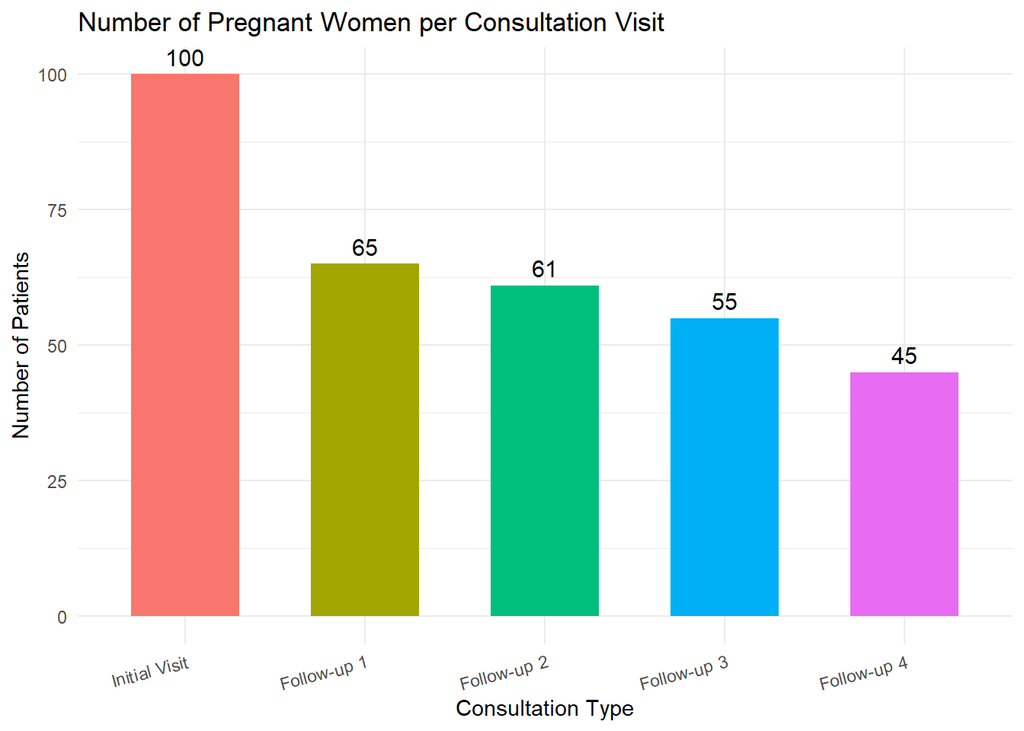

2. Age Distribution

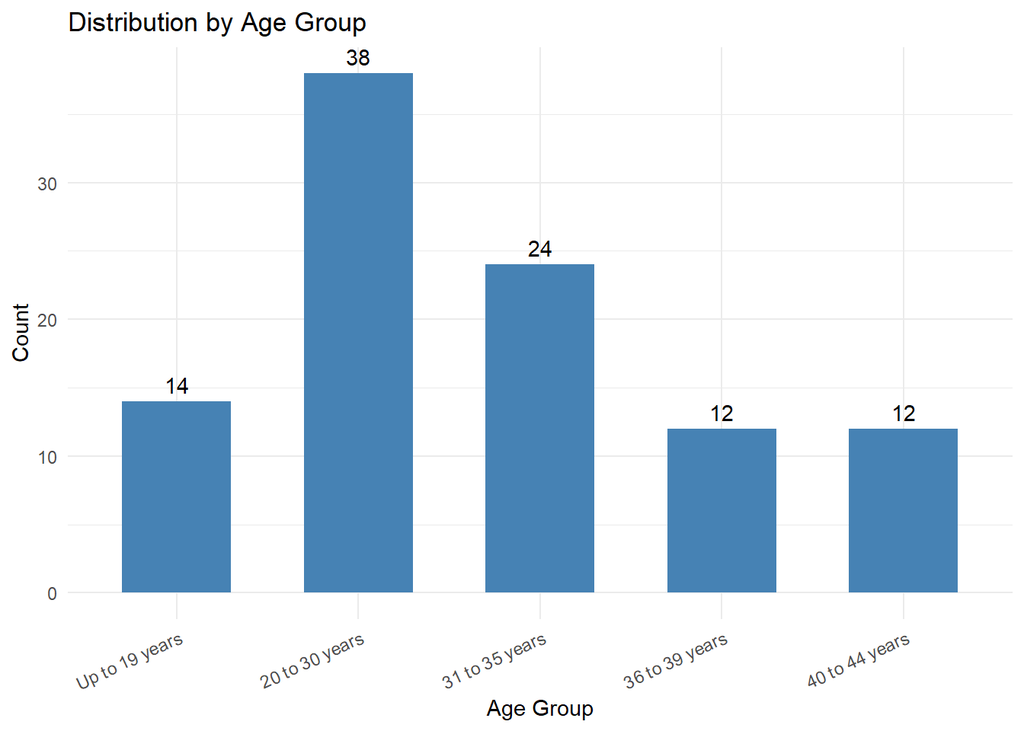

3. Number of Pregnancies

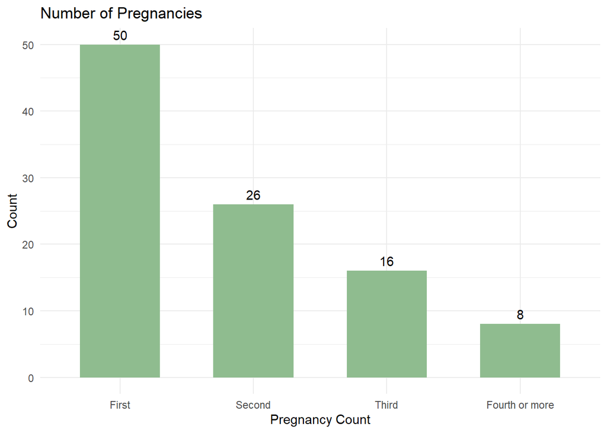

4. Gestational age at first appointment

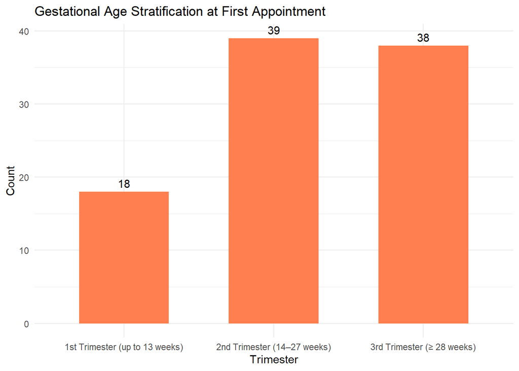

5. Pre-gestational BMI Classification

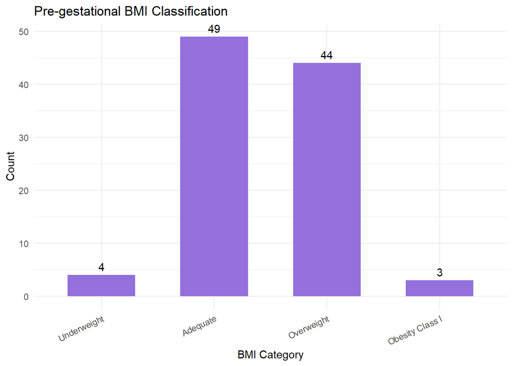

6. Blood Glucose Monitoring

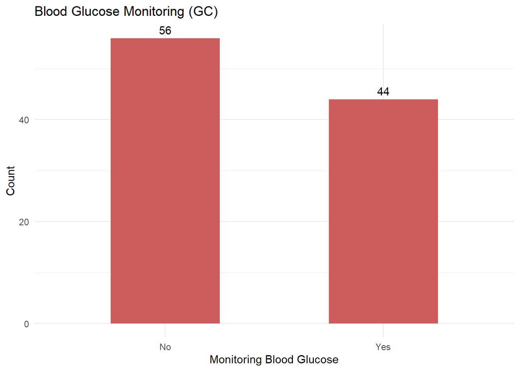

7. Nutritional Diagnosis at First Consultation

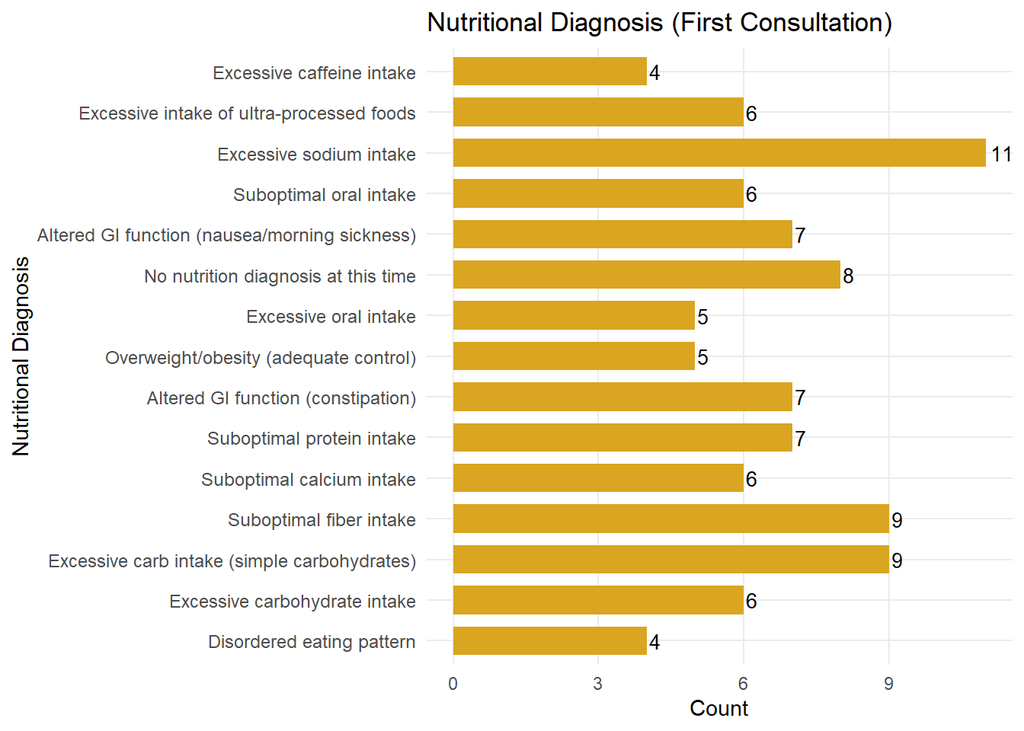

## Interventions

1. Meal Plan Adherence

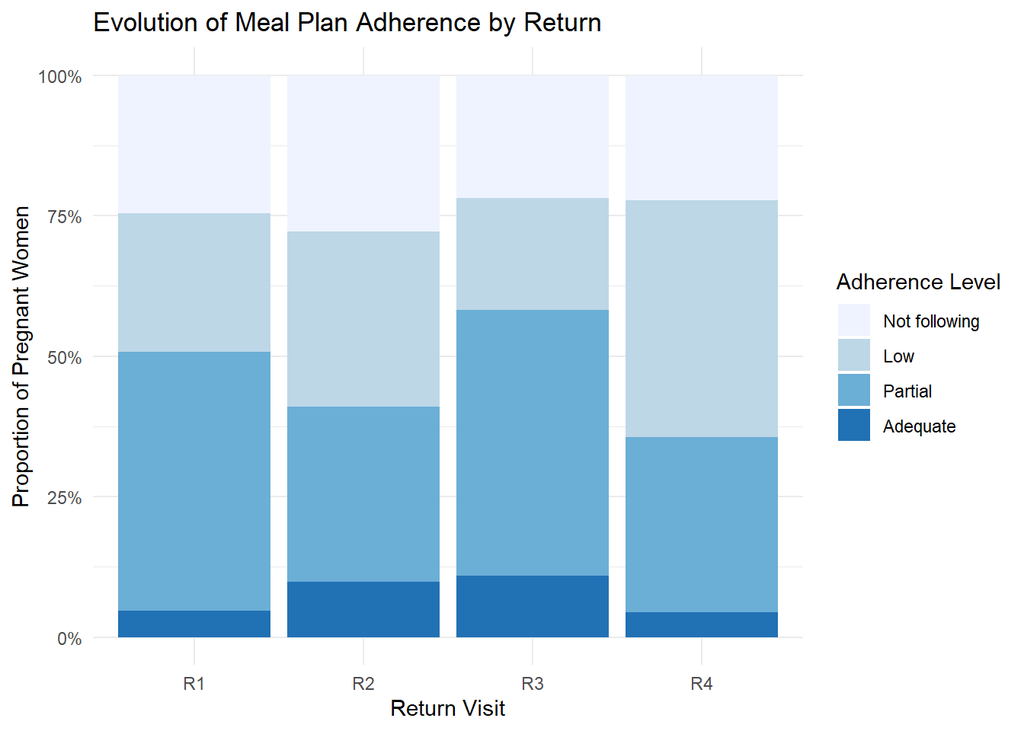

2. Weight Control

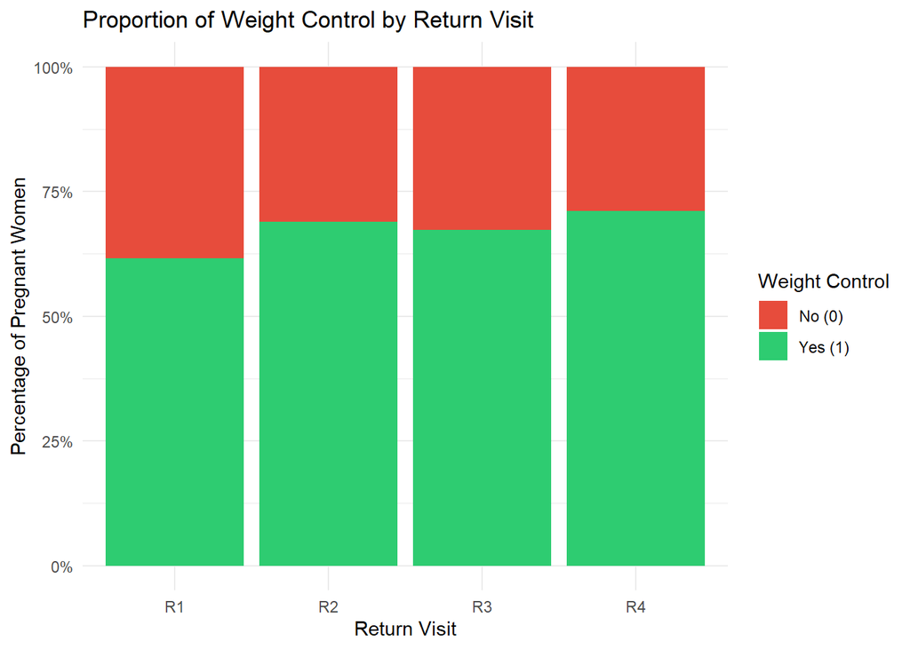

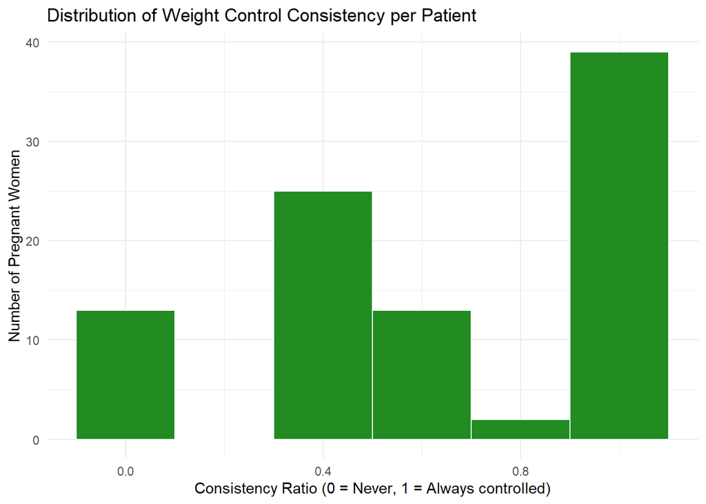

3. Glycemic Control

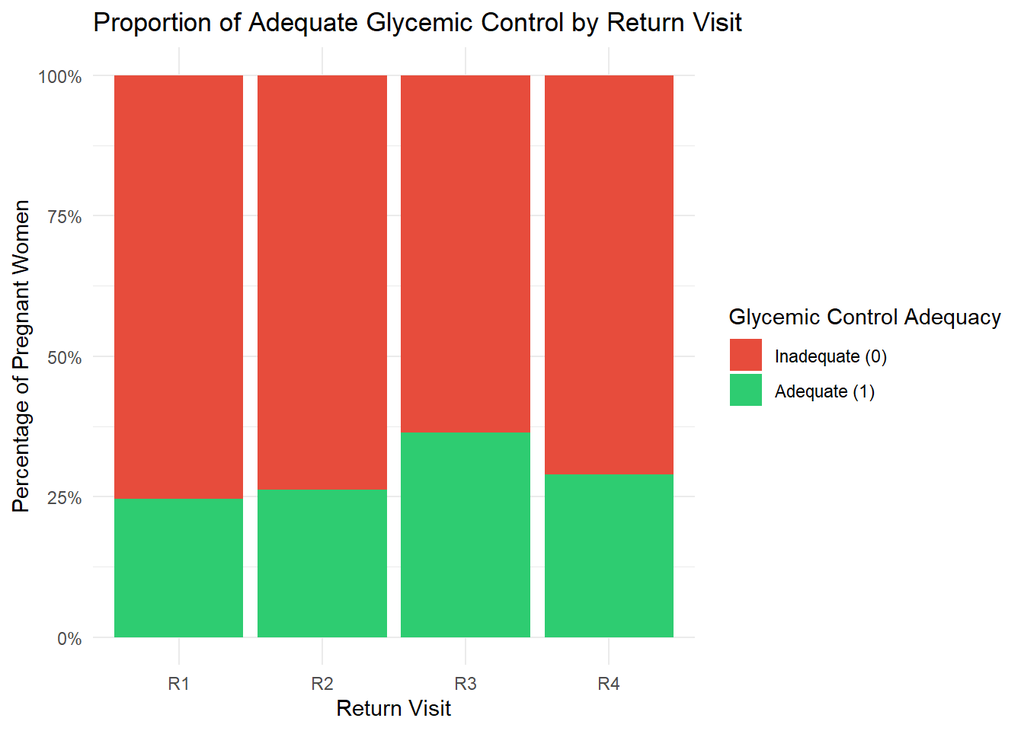

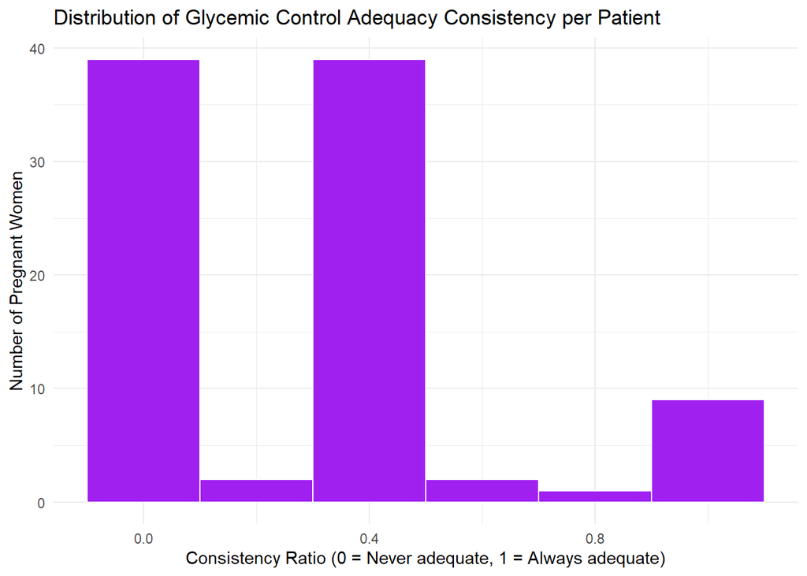

4. Insulin Use

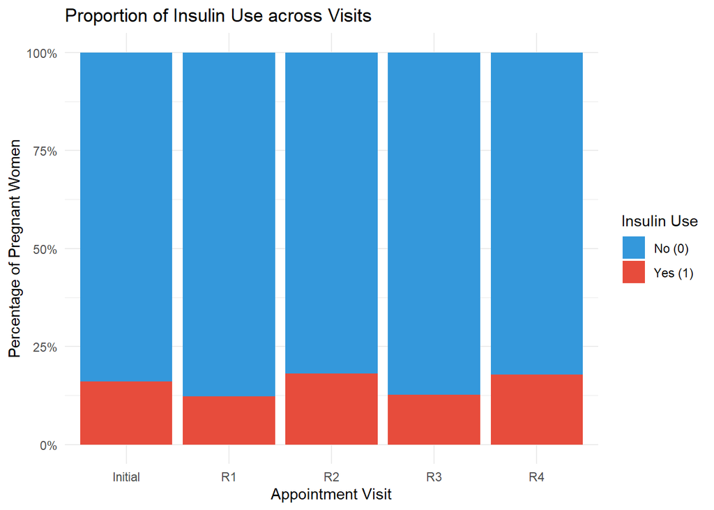

5. Main Nutritional Diagnoses

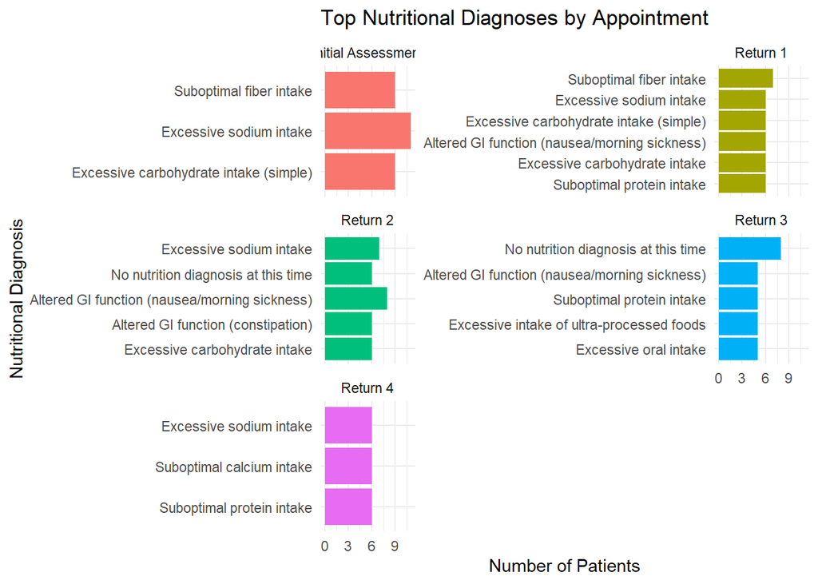

6. Correlations between Glycemic Control & Meal Plan Adherence, Weight Control, Insulin Use, Nutritional Diagnoses

```r
df_long_gc <- pregnancy_df %>%
  dplyr::select(System_number,
         starts_with("GC_adequate_R"),
         starts_with("Meal_plan_adherence_R"),
         starts_with("Weight_control_R"),
         starts_with("Insulin_use_R"),
         starts_with("Nutritional_diagnosis_R")) %>%
  pivot_longer(
    cols = -System_number,
    names_to = c(".value", "Return"),
    names_pattern = "(.*)_(R[1-4])"
  ) %>%
  mutate(
    Return = factor(Return, levels = c("R1", "R2", "R3", "R4")),
    System_number = as.factor(System_number),
    # Convert Nutritional diagnosis to factor if treating categorically
    Nutritional_diagnosis = as.factor(Nutritional_diagnosis)
  ) %>%
  drop_na(GC_adequate) # Keep rows where glycemic control outcome is available

# Check the prepared data
head(df_long_gc)
```

```
## # A tibble: 6 × 7
##   System_number Return GC_adequate Meal_plan_adherence Weight_control
##   <fct>         <fct>        <dbl>               <int>          <int>
## 1 SYS-10001     R1               0                   2              0
## 2 SYS-10001     R2               1                   1              0
## 3 SYS-10001     R3               1                   1              1
## 4 SYS-10001     R4               0                   0              1
## 5 SYS-10002     R2               0                   0              1
## 6 SYS-10002     R3               0                   2              0
## # ℹ 2 more variables: Insulin_use <int>, Nutritional_diagnosis <fct>
```

```r
# Fit Logistic GEE model with GC_adequate as the outcome
gee_gc_comparison <- geeglm(
  GC_adequate ~ Return + Meal_plan_adherence + Weight_control + Insulin_use + Nutritional_diagnosis,
  id = System_number,
  data = df_long_gc %>% drop_na(Meal_plan_adherence, Weight_control, Insulin_use, Nutritional_diagnosis),
  family = binomial(link = "logit"),
  corstr = "exchangeable" # Assumes uniform correlation across the 4 return visits
)

# View the comprehensive model summary
summary(gee_gc_comparison)
```

```
##
## Call:
## geeglm(formula = GC_adequate ~ Return + Meal_plan_adherence +
##     Weight_control + Insulin_use + Nutritional_diagnosis, family = binomial(link = "logit"),
##     data = df_long_gc %>% drop_na(Meal_plan_adherence, Weight_control,
##         Insulin_use, Nutritional_diagnosis), id = System_number,
##     corstr = "exchangeable")
##
##  Coefficients:
##                         Estimate  Std.err   Wald Pr(>|W|)
## (Intercept)             -2.60435  0.80166 10.554  0.00116 **
## ReturnR2                 0.14699  0.47990  0.094  0.75939
## ReturnR3                 0.31271  0.44293  0.498  0.48019
## ReturnR4                 0.11013  0.46599  0.056  0.81317
## Meal_plan_adherence      0.26024  0.16593  2.460  0.11680
## Weight_control           0.81870  0.36007  5.170  0.02298 *
## Insulin_use             -0.08826  0.39445  0.050  0.82295
## Nutritional_diagnosis2   0.04454  1.00202  0.002  0.96454
## Nutritional_diagnosis3   0.41935  0.94893  0.195  0.65855
## Nutritional_diagnosis4   1.15714  0.87697  1.741  0.18701
## Nutritional_diagnosis5   1.00405  0.89408  1.261  0.26144
## Nutritional_diagnosis6   0.54766  0.84926  0.416  0.51902
## Nutritional_diagnosis7   0.06962  1.00176  0.005  0.94460
## Nutritional_diagnosis8   0.11120  0.96592  0.013  0.90835
## Nutritional_diagnosis9   1.40563  0.88501  2.523  0.11222
## Nutritional_diagnosis10  1.11840  0.81989  1.861  0.17254
## Nutritional_diagnosis11  0.02832  0.92177  0.001  0.97549
## Nutritional_diagnosis12  1.68237  0.88239  3.635  0.05657 .
## Nutritional_diagnosis13  0.74773  0.83379  0.804  0.36983
## Nutritional_diagnosis14  0.82610  0.93902  0.774  0.37900
## Nutritional_diagnosis15  0.53414  0.83974  0.405  0.52473
## ---
## Signif. codes:  0 '***' 0.001 '**' 0.01 '*' 0.05 '.' 0.1 ' ' 1
##
## Correlation structure = exchangeable
## Estimated Scale Parameters:
##
##             Estimate Std.err
## (Intercept)    1.047  0.3847
##   Link = identity
##
## Estimated Correlation Parameters:
##       Estimate Std.err
## alpha -0.09818 0.08417
## Number of clusters:   92  Maximum cluster size: 4
```

Using a Generalized Estimating Equations (GEE) model with GC_adequate as the outcome, it is observed that successful weight control is a strong and statistically significant predictor of adequate glycemic control ($p = 0.023$, $\text{OR} \approx 2.27$).

Regarding meal plan adherence, the positive estimate (Estimate = $0.2602$, $p = 0.1168$) indicates that higher adherence scores lean toward better glycemic control, but this trend did not reach statistical significance at the $0.05$ level in this multivariable model.

Considering the nutritional diagnoses, most categories do not show a statistically significant difference, except category 12 (Suboptimal oral intake), which approaches significance at $p = 0.0566$).

None of the return visits show a statistically significant difference compared to Return 1 ($p > 0.40$). This indicates that the overall baseline rate of adequate glycemic control remained relatively stable across the sequential visits. The insulin use was also not statistically significant, likely because insulin is prescribed to manage more severe cases, acting as a clinical confounder in this model.

# Social Determinants of Health (SDOH)

1. Household Earnings (monthly)

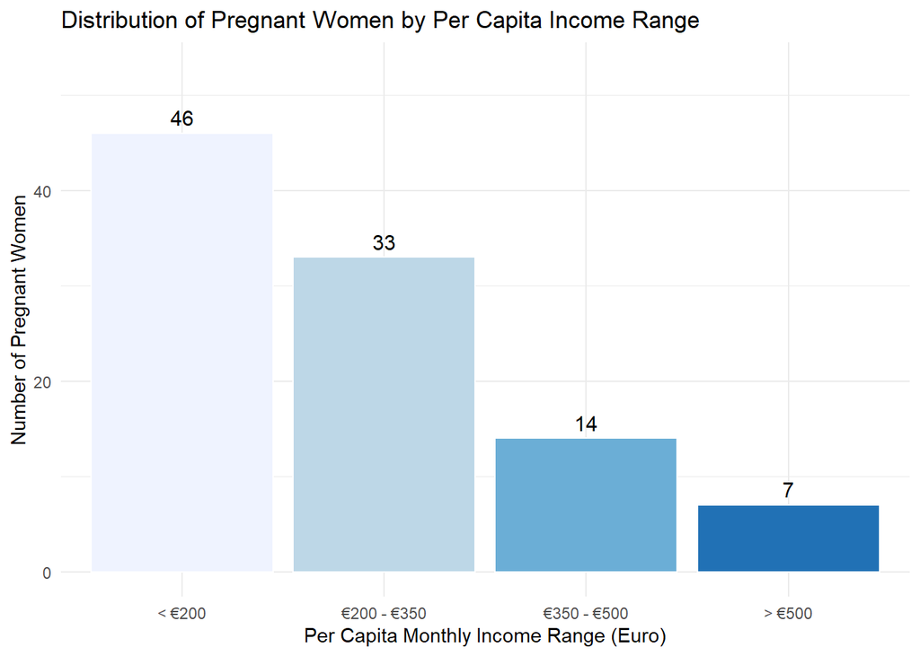

2. Income Classification

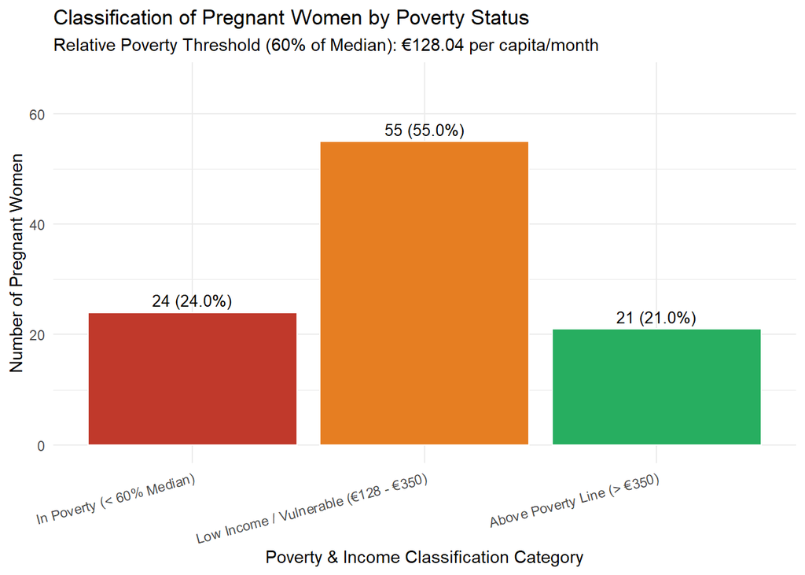

3. Pre Gestacional Body Mass Index and Per Capita Household Earnings (Monthly)

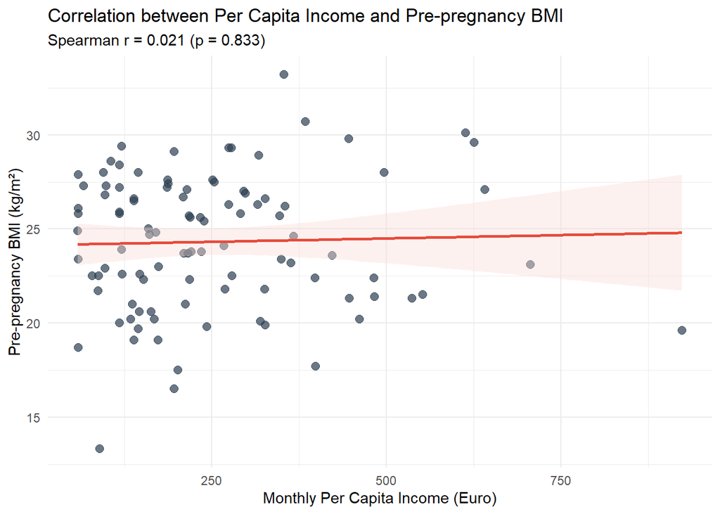

4. Government Benefits

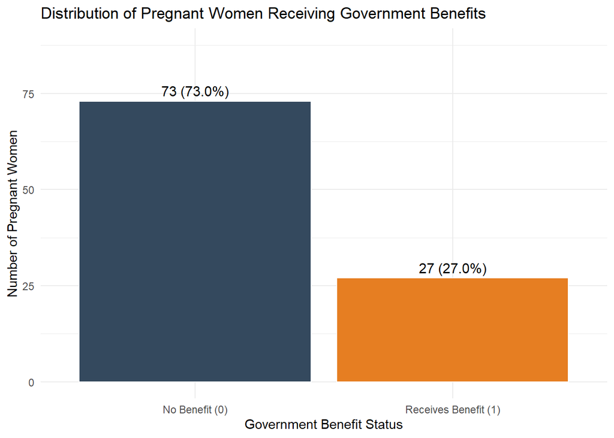

5. Weight Control and Household Earnings (Monthly)

```
##
## Call:
## geeglm(formula = Weight_control ~ Return + Monthly_income_eur,
##     family = binomial(link = "logit"), data = df_long_weight,
##     id = System_number, corstr = "exchangeable")
##
##  Coefficients:
##                     Estimate   Std.err Wald Pr(>|W|)
## (Intercept)         1.104731  0.494890 4.98    0.026 *
## ReturnR2            0.283321  0.385359 0.54    0.462
## ReturnR3            0.250019  0.374384 0.45    0.504
## ReturnR4            0.415252  0.391572 1.12    0.289
## Monthly_income_eur -0.001064  0.000683 2.42    0.120
## ---
## Signif. codes:  0 '***' 0.001 '**' 0.01 '*' 0.05 '.' 0.1 ' ' 1
##
## Correlation structure = exchangeable
## Estimated Scale Parameters:
##
##             Estimate Std.err
## (Intercept)    0.999  0.0682
##   Link = identity
##
## Estimated Correlation Parameters:
##       Estimate Std.err
## alpha   0.0392  0.0575
## Number of clusters:   92  Maximum cluster size: 4
```

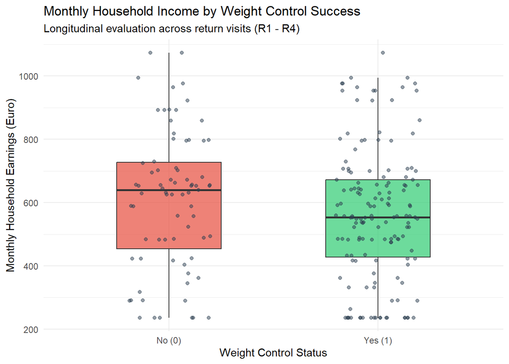

The longitudinal GEE model indicated that neither the follow-up time (visits R2 through R4 compared to R1) nor the participants’ monthly income (Monthly_income_eur) showed a statistically significant association with the probability of success in weight control ($p > 0.05$). These findings suggest that success in weight control was consistent across the consultations and independent of family income within the group evaluated.

6. Weight Control and Government Benefits

```
## [1] "--- GEE Model Output: Weight Control vs Government Benefits ---"
```

```
##
## Call:
## geeglm(formula = Weight_control ~ Return + Government_benefit,
##     family = binomial(link = "logit"), data = df_long_benefit,
##     id = System_number, corstr = "exchangeable")
##
##  Coefficients:
##                    Estimate Std.err Wald Pr(>|W|)
## (Intercept)           0.397   0.266 2.24     0.13
## ReturnR2              0.280   0.388 0.52     0.47
## ReturnR3              0.234   0.370 0.40     0.53
## ReturnR4              0.408   0.392 1.08     0.30
## Government_benefit    0.387   0.345 1.26     0.26
##
## Correlation structure = exchangeable
## Estimated Scale Parameters:
##
##             Estimate Std.err
## (Intercept)    0.997  0.0604
##   Link = identity
##
## Estimated Correlation Parameters:
##       Estimate Std.err
## alpha   0.0439  0.0582
## Number of clusters:   92  Maximum cluster size: 4
```

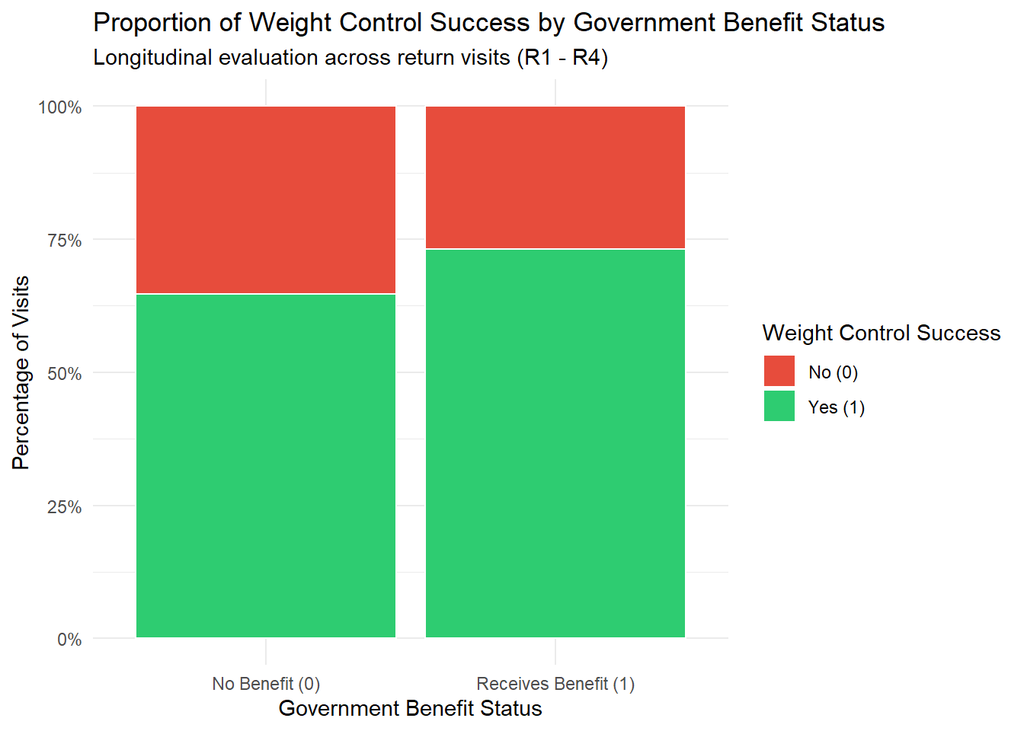